# Risk Factor Analysis

## Outcome Variable

**Outcome Variable:** sstunted

## Predictor Variables

**Intervention Variable:** nrooms

**Adjustment Set:**

- arm
- sex
- W_mage
- meducyrs
- feducyrs
- hhwealth_quart
- hfoodsec
- W_mhtcm
- W_nchldlt5
- W_parity
- impfloor
- impsan
- safeh20
- delta_W_mage
- delta_meducyrs
- delta_feducyrs
- delta_hhwealth_quart
- delta_hfoodsec
- delta_W_mhtcm
- delta_W_nchldlt5
- delta_W_parity
- delta_impfloor
- delta_impsan
- delta_safeh20

## Stratifying Variables

The analysis was stratified on these variable(s):

- agecat
- studyid
- country

## Data Summary

| agecat | studyid | country | nrooms | sstunted | n_cell | n |
| --- | --- | --- | --- | --- | --- | --- |
| Birth | ki0047075b-MAL-ED | BANGLADESH | 4+ | 0 | 12 | 234 |
| Birth | ki0047075b-MAL-ED | BANGLADESH | 4+ | 1 | 0 | 234 |
| Birth | ki0047075b-MAL-ED | BANGLADESH | 1 | 0 | 139 | 234 |
| Birth | ki0047075b-MAL-ED | BANGLADESH | 1 | 1 | 5 | 234 |
| Birth | ki0047075b-MAL-ED | BANGLADESH | 2 | 0 | 49 | 234 |
| Birth | ki0047075b-MAL-ED | BANGLADESH | 2 | 1 | 1 | 234 |
| Birth | ki0047075b-MAL-ED | BANGLADESH | 3 | 0 | 28 | 234 |
| Birth | ki0047075b-MAL-ED | BANGLADESH | 3 | 1 | 0 | 234 |
| Birth | ki0047075b-MAL-ED | BRAZIL | 4+ | 0 | 99 | 174 |
| Birth | ki0047075b-MAL-ED | BRAZIL | 4+ | 1 | 3 | 174 |
| Birth | ki0047075b-MAL-ED | BRAZIL | 1 | 0 | 3 | 174 |
| Birth | ki0047075b-MAL-ED | BRAZIL | 1 | 1 | 0 | 174 |
| Birth | ki0047075b-MAL-ED | BRAZIL | 2 | 0 | 19 | 174 |
| Birth | ki0047075b-MAL-ED | BRAZIL | 2 | 1 | 0 | 174 |
| Birth | ki0047075b-MAL-ED | BRAZIL | 3 | 0 | 46 | 174 |
| Birth | ki0047075b-MAL-ED | BRAZIL | 3 | 1 | 4 | 174 |
| Birth | ki0047075b-MAL-ED | INDIA | 4+ | 0 | 22 | 191 |
| Birth | ki0047075b-MAL-ED | INDIA | 4+ | 1 | 0 | 191 |
| Birth | ki0047075b-MAL-ED | INDIA | 1 | 0 | 67 | 191 |
| Birth | ki0047075b-MAL-ED | INDIA | 1 | 1 | 2 | 191 |
| Birth | ki0047075b-MAL-ED | INDIA | 2 | 0 | 64 | 191 |
| Birth | ki0047075b-MAL-ED | INDIA | 2 | 1 | 4 | 191 |
| Birth | ki0047075b-MAL-ED | INDIA | 3 | 0 | 31 | 191 |
| Birth | ki0047075b-MAL-ED | INDIA | 3 | 1 | 1 | 191 |
| Birth | ki0047075b-MAL-ED | NEPAL | 4+ | 0 | 94 | 171 |
| Birth | ki0047075b-MAL-ED | NEPAL | 4+ | 1 | 3 | 171 |
| Birth | ki0047075b-MAL-ED | NEPAL | 1 | 0 | 33 | 171 |
| Birth | ki0047075b-MAL-ED | NEPAL | 1 | 1 | 3 | 171 |
| Birth | ki0047075b-MAL-ED | NEPAL | 2 | 0 | 21 | 171 |
| Birth | ki0047075b-MAL-ED | NEPAL | 2 | 1 | 0 | 171 |

[output cut: 338 more lines]

The following strata were considered:

- agecat: 24 months, studyid: ki0047075b-MAL-ED, country: BANGLADESH
- agecat: 24 months, studyid: ki0047075b-MAL-ED, country: BRAZIL
- agecat: 24 months, studyid: ki0047075b-MAL-ED, country: INDIA
- agecat: 24 months, studyid: ki0047075b-MAL-ED, country: NEPAL
- agecat: 24 months, studyid: ki0047075b-MAL-ED, country: PERU
- agecat: 24 months, studyid: ki0047075b-MAL-ED, country: SOUTH AFRICA
- agecat: 24 months, studyid: ki0047075b-MAL-ED, country: TANZANIA, UNITED REPUBLIC OF
- agecat: 24 months, studyid: ki1000108-CMC-V-BCS-2002, country: INDIA
- agecat: 24 months, studyid: ki1000108-IRC, country: INDIA
- agecat: 24 months, studyid: ki1017093b-PROVIDE, country: BANGLADESH
- agecat: 24 months, studyid: ki1017093c-NIH-Crypto, country: BANGLADESH
- agecat: 24 months, studyid: ki1113344-GMS-Nepal, country: NEPAL
- agecat: 24 months, studyid: ki1114097-CONTENT, country: PERU
- agecat: 24 months, studyid: ki1135781-COHORTS, country: INDIA
- agecat: 24 months, studyid: kiGH5241-JiVitA-3, country: BANGLADESH
- agecat: 24 months, studyid: kiGH5241-JiVitA-4, country: BANGLADESH
- agecat: 6 months, studyid: ki0047075b-MAL-ED, country: BANGLADESH
- agecat: 6 months, studyid: ki0047075b-MAL-ED, country: BRAZIL
- agecat: 6 months, studyid: ki0047075b-MAL-ED, country: INDIA
- agecat: 6 months, studyid: ki0047075b-MAL-ED, country: NEPAL
- agecat: 6 months, studyid: ki0047075b-MAL-ED, country: PERU
- agecat: 6 months, studyid: ki0047075b-MAL-ED, country: SOUTH AFRICA
- agecat: 6 months, studyid: ki0047075b-MAL-ED, country: TANZANIA, UNITED REPUBLIC OF
- agecat: 6 months, studyid: ki1000108-CMC-V-BCS-2002, country: INDIA
- agecat: 6 months, studyid: ki1000108-IRC, country: INDIA
- agecat: 6 months, studyid: ki1017093b-PROVIDE, country: BANGLADESH
- agecat: 6 months, studyid: ki1017093c-NIH-Crypto, country: BANGLADESH
- agecat: 6 months, studyid: ki1113344-GMS-Nepal, country: NEPAL
- agecat: 6 months, studyid: ki1114097-CONTENT, country: PERU
- agecat: 6 months, studyid: ki1135781-COHORTS, country: INDIA
- agecat: 6 months, studyid: kiGH5241-JiVitA-3, country: BANGLADESH
- agecat: 6 months, studyid: kiGH5241-JiVitA-4, country: BANGLADESH
- agecat: Birth, studyid: ki0047075b-MAL-ED, country: BANGLADESH
- agecat: Birth, studyid: ki0047075b-MAL-ED, country: BRAZIL
- agecat: Birth, studyid: ki0047075b-MAL-ED, country: INDIA
- agecat: Birth, studyid: ki0047075b-MAL-ED, country: NEPAL
- agecat: Birth, studyid: ki0047075b-MAL-ED, country: PERU
- agecat: Birth, studyid: ki0047075b-MAL-ED, country: SOUTH AFRICA
- agecat: Birth, studyid: ki0047075b-MAL-ED, country: TANZANIA, UNITED REPUBLIC OF
- agecat: Birth, studyid: ki1000108-CMC-V-BCS-2002, country: INDIA
- agecat: Birth, studyid: ki1000108-IRC, country: INDIA
- agecat: Birth, studyid: ki1017093c-NIH-Crypto, country: BANGLADESH
- agecat: Birth, studyid: ki1114097-CONTENT, country: PERU
- agecat: Birth, studyid: ki1135781-COHORTS, country: INDIA
- agecat: Birth, studyid: kiGH5241-JiVitA-3, country: BANGLADESH
- agecat: Birth, studyid: kiGH5241-JiVitA-4, country: BANGLADESH

### Dropped Strata

Some strata were dropped due to rare outcomes:

- agecat: Birth, studyid: ki0047075b-MAL-ED, country: BANGLADESH
- agecat: Birth, studyid: ki0047075b-MAL-ED, country: BRAZIL
- agecat: Birth, studyid: ki0047075b-MAL-ED, country: INDIA
- agecat: Birth, studyid: ki0047075b-MAL-ED, country: NEPAL
- agecat: Birth, studyid: ki0047075b-MAL-ED, country: PERU
- agecat: Birth, studyid: ki0047075b-MAL-ED, country: SOUTH AFRICA
- agecat: Birth, studyid: ki0047075b-MAL-ED, country: TANZANIA, UNITED REPUBLIC OF
- agecat: Birth, studyid: ki1000108-CMC-V-BCS-2002, country: INDIA
- agecat: Birth, studyid: ki1000108-IRC, country: INDIA
- agecat: Birth, studyid: ki1017093c-NIH-Crypto, country: BANGLADESH
- agecat: Birth, studyid: ki1114097-CONTENT, country: PERU
- agecat: Birth, studyid: ki1135781-COHORTS, country: INDIA
- agecat: Birth, studyid: kiGH5241-JiVitA-4, country: BANGLADESH
- agecat: 6 months, studyid: ki0047075b-MAL-ED, country: BANGLADESH
- agecat: 6 months, studyid: ki0047075b-MAL-ED, country: BRAZIL
- agecat: 6 months, studyid: ki0047075b-MAL-ED, country: INDIA
- agecat: 6 months, studyid: ki0047075b-MAL-ED, country: NEPAL
- agecat: 6 months, studyid: ki0047075b-MAL-ED, country: PERU
- agecat: 6 months, studyid: ki0047075b-MAL-ED, country: SOUTH AFRICA
- agecat: 6 months, studyid: ki0047075b-MAL-ED, country: TANZANIA, UNITED REPUBLIC OF
- agecat: 6 months, studyid: ki1000108-CMC-V-BCS-2002, country: INDIA
- agecat: 6 months, studyid: ki1000108-IRC, country: INDIA
- agecat: 6 months, studyid: ki1017093b-PROVIDE, country: BANGLADESH
- agecat: 6 months, studyid: ki1017093c-NIH-Crypto, country: BANGLADESH
- agecat: 6 months, studyid: ki1113344-GMS-Nepal, country: NEPAL
- agecat: 6 months, studyid: ki1114097-CONTENT, country: PERU
- agecat: 6 months, studyid: ki1135781-COHORTS, country: INDIA
- agecat: 24 months, studyid: ki0047075b-MAL-ED, country: BANGLADESH
- agecat: 24 months, studyid: ki0047075b-MAL-ED, country: BRAZIL
- agecat: 24 months, studyid: ki0047075b-MAL-ED, country: INDIA
- agecat: 24 months, studyid: ki0047075b-MAL-ED, country: NEPAL
- agecat: 24 months, studyid: ki0047075b-MAL-ED, country: PERU
- agecat: 24 months, studyid: ki0047075b-MAL-ED, country: SOUTH AFRICA
- agecat: 24 months, studyid: ki0047075b-MAL-ED, country: TANZANIA, UNITED REPUBLIC OF
- agecat: 24 months, studyid: ki1000108-CMC-V-BCS-2002, country: INDIA
- agecat: 24 months, studyid: ki1000108-IRC, country: INDIA
- agecat: 24 months, studyid: ki1017093b-PROVIDE, country: BANGLADESH
- agecat: 24 months, studyid: ki1017093c-NIH-Crypto, country: BANGLADESH
- agecat: 24 months, studyid: ki1114097-CONTENT, country: PERU
- agecat: 24 months, studyid: ki1135781-COHORTS, country: INDIA

## Methods Detail

We’re interested in the causal parameters $E[Y_a]$ for all values of $a \in \mathcal{A}$. These parameters represent the mean outcome if, possibly contrary to fact, we intervened to set all units to have $A=a$. Under the randomization and positivity assumptions, these are identified by the statistical parameters $\psi_a=E_W[E_{Y|A,W}(Y|A=a,W)]$. In addition, we’re interested in the mean of $Y$, $E[Y]$ under no intervention (the observed mean). We will estimate these parameters by using SuperLearner to fit the relevant likelihood factors – $E_{Y|A,W}(Y|A=a,W)$ and $p(A=a|W)$, and then updating our likelihood fit using a joint TMLE.

For unadjusted analyses ($W=\{\}$), initial likelihoods were estimated using Lrnr_glm to estimate the simple $E(Y|A)$ and Lrnr_mean to estimate $p(A)$. For adjusted analyses, a small library containing Lrnr_glmnet, Lrnr_xgboost, and Lrnr_mean was used.

Having estimated these parameters, we will then use the delta method to estimate relative risks and attributable risks relative to a prespecified baseline level of $A$.

# Results Detail

## Results Plots

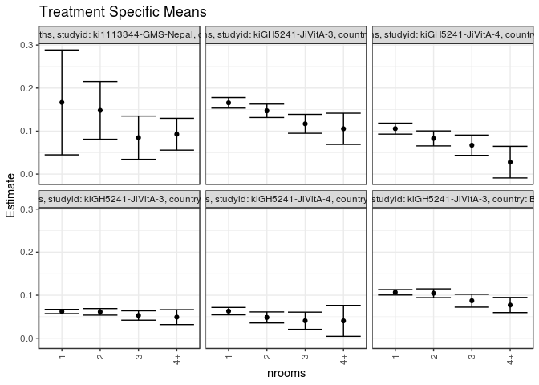

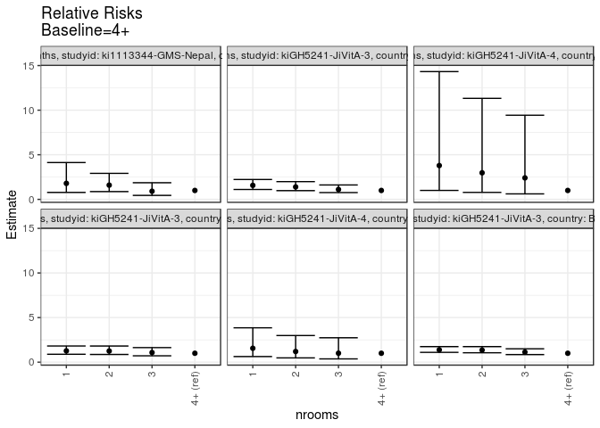

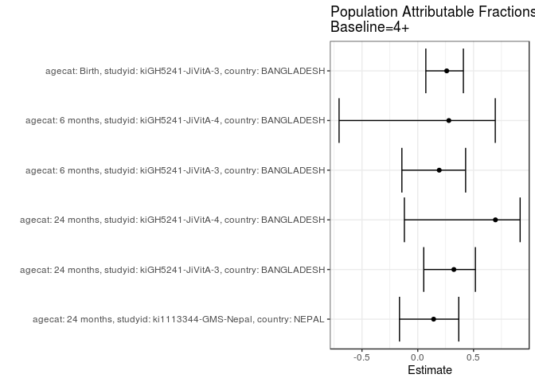

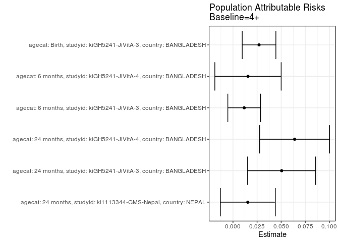

## Results Table

### Parameter: TSM

| agecat | studyid | country | intervention_level | baseline_level | estimate | ci_lower | ci_upper |
| --- | --- | --- | --- | --- | --- | --- | --- |
| Birth | kiGH5241-JiVitA-3 | BANGLADESH | 4+ | NA | 0.0771439 | 0.0595493 | 0.0947384 |
| Birth | kiGH5241-JiVitA-3 | BANGLADESH | 1 | NA | 0.1067900 | 0.1005228 | 0.1130572 |
| Birth | kiGH5241-JiVitA-3 | BANGLADESH | 2 | NA | 0.1045530 | 0.0943158 | 0.1147901 |
| Birth | kiGH5241-JiVitA-3 | BANGLADESH | 3 | NA | 0.0871801 | 0.0722390 | 0.1021211 |
| 6 months | kiGH5241-JiVitA-3 | BANGLADESH | 4+ | NA | 0.0489820 | 0.0316927 | 0.0662713 |
| 6 months | kiGH5241-JiVitA-3 | BANGLADESH | 1 | NA | 0.0620781 | 0.0570590 | 0.0670972 |
| 6 months | kiGH5241-JiVitA-3 | BANGLADESH | 2 | NA | 0.0612680 | 0.0536305 | 0.0689056 |
| 6 months | kiGH5241-JiVitA-3 | BANGLADESH | 3 | NA | 0.0528262 | 0.0418676 | 0.0637847 |
| 6 months | kiGH5241-JiVitA-4 | BANGLADESH | 4+ | NA | 0.0403647 | 0.0043250 | 0.0764043 |
| 6 months | kiGH5241-JiVitA-4 | BANGLADESH | 1 | NA | 0.0629466 | 0.0543273 | 0.0715658 |
| 6 months | kiGH5241-JiVitA-4 | BANGLADESH | 2 | NA | 0.0482914 | 0.0354545 | 0.0611284 |
| 6 months | kiGH5241-JiVitA-4 | BANGLADESH | 3 | NA | 0.0405785 | 0.0205740 | 0.0605830 |
| 24 months | ki1113344-GMS-Nepal | NEPAL | 4+ | NA | 0.0928270 | 0.0558449 | 0.1298091 |
| 24 months | ki1113344-GMS-Nepal | NEPAL | 1 | NA | 0.1666667 | 0.0448053 | 0.2885281 |
| 24 months | ki1113344-GMS-Nepal | NEPAL | 2 | NA | 0.1481481 | 0.0810822 | 0.2152141 |
| 24 months | ki1113344-GMS-Nepal | NEPAL | 3 | NA | 0.0847458 | 0.0344452 | 0.1350463 |
| 24 months | kiGH5241-JiVitA-3 | BANGLADESH | 4+ | NA | 0.1054338 | 0.0690753 | 0.1417923 |
| 24 months | kiGH5241-JiVitA-3 | BANGLADESH | 1 | NA | 0.1657877 | 0.1534773 | 0.1780981 |
| 24 months | kiGH5241-JiVitA-3 | BANGLADESH | 2 | NA | 0.1472085 | 0.1316754 | 0.1627415 |
| 24 months | kiGH5241-JiVitA-3 | BANGLADESH | 3 | NA | 0.1170387 | 0.0950282 | 0.1390492 |
| 24 months | kiGH5241-JiVitA-4 | BANGLADESH | 4+ | NA | 0.0278884 | -0.0089281 | 0.0647049 |
| 24 months | kiGH5241-JiVitA-4 | BANGLADESH | 1 | NA | 0.1057727 | 0.0930611 | 0.1184843 |
| 24 months | kiGH5241-JiVitA-4 | BANGLADESH | 2 | NA | 0.0830592 | 0.0656273 | 0.1004911 |
| 24 months | kiGH5241-JiVitA-4 | BANGLADESH | 3 | NA | 0.0672098 | 0.0435944 | 0.0908252 |

### Parameter: E(Y)

| agecat | studyid | country | intervention_level | baseline_level | estimate | ci_lower | ci_upper |
| --- | --- | --- | --- | --- | --- | --- | --- |
| Birth | kiGH5241-JiVitA-3 | BANGLADESH | NA | NA | 0.1041911 | 0.0995153 | 0.1088669 |
| 6 months | kiGH5241-JiVitA-3 | BANGLADESH | NA | NA | 0.0606548 | 0.0568001 | 0.0645094 |
| 6 months | kiGH5241-JiVitA-4 | BANGLADESH | NA | NA | 0.0559585 | 0.0491999 | 0.0627172 |
| 24 months | ki1113344-GMS-Nepal | NEPAL | NA | NA | 0.1082164 | 0.0809323 | 0.1355005 |
| 24 months | kiGH5241-JiVitA-3 | BANGLADESH | NA | NA | 0.1559165 | 0.1471734 | 0.1646596 |
| 24 months | kiGH5241-JiVitA-4 | BANGLADESH | NA | NA | 0.0918475 | 0.0824775 | 0.1012175 |

### Parameter: RR

| agecat | studyid | country | intervention_level | baseline_level | estimate | ci_lower | ci_upper |
| --- | --- | --- | --- | --- | --- | --- | --- |
| Birth | kiGH5241-JiVitA-3 | BANGLADESH | 4+ | 4+ | 1.000000 | 1.0000000 | 1.000000 |
| Birth | kiGH5241-JiVitA-3 | BANGLADESH | 1 | 4+ | 1.384296 | 1.0990633 | 1.743554 |
| Birth | kiGH5241-JiVitA-3 | BANGLADESH | 2 | 4+ | 1.355298 | 1.0533920 | 1.743732 |
| Birth | kiGH5241-JiVitA-3 | BANGLADESH | 3 | 4+ | 1.130097 | 0.8500390 | 1.502424 |
| 6 months | kiGH5241-JiVitA-3 | BANGLADESH | 4+ | 4+ | 1.000000 | 1.0000000 | 1.000000 |
| 6 months | kiGH5241-JiVitA-3 | BANGLADESH | 1 | 4+ | 1.267365 | 0.8856092 | 1.813682 |
| 6 months | kiGH5241-JiVitA-3 | BANGLADESH | 2 | 4+ | 1.250827 | 0.8640120 | 1.810818 |
| 6 months | kiGH5241-JiVitA-3 | BANGLADESH | 3 | 4+ | 1.078481 | 0.7128214 | 1.631715 |
| 6 months | kiGH5241-JiVitA-4 | BANGLADESH | 4+ | 4+ | 1.000000 | 1.0000000 | 1.000000 |
| 6 months | kiGH5241-JiVitA-4 | BANGLADESH | 1 | 4+ | 1.559448 | 0.6312233 | 3.852642 |
| 6 months | kiGH5241-JiVitA-4 | BANGLADESH | 2 | 4+ | 1.196379 | 0.4792812 | 2.986392 |
| 6 months | kiGH5241-JiVitA-4 | BANGLADESH | 3 | 4+ | 1.005297 | 0.3692393 | 2.737041 |
| 24 months | ki1113344-GMS-Nepal | NEPAL | 4+ | 4+ | 1.000000 | 1.0000000 | 1.000000 |
| 24 months | ki1113344-GMS-Nepal | NEPAL | 1 | 4+ | 1.795454 | 0.7808242 | 4.128531 |
| 24 months | ki1113344-GMS-Nepal | NEPAL | 2 | 4+ | 1.595960 | 0.8732249 | 2.916874 |
| 24 months | ki1113344-GMS-Nepal | NEPAL | 3 | 4+ | 0.912943 | 0.4466691 | 1.865956 |
| 24 months | kiGH5241-JiVitA-3 | BANGLADESH | 4+ | 4+ | 1.000000 | 1.0000000 | 1.000000 |
| 24 months | kiGH5241-JiVitA-3 | BANGLADESH | 1 | 4+ | 1.572434 | 1.1095913 | 2.228342 |
| 24 months | kiGH5241-JiVitA-3 | BANGLADESH | 2 | 4+ | 1.396217 | 0.9792284 | 1.990774 |
| 24 months | kiGH5241-JiVitA-3 | BANGLADESH | 3 | 4+ | 1.110068 | 0.7629265 | 1.615164 |
| 24 months | kiGH5241-JiVitA-4 | BANGLADESH | 4+ | 4+ | 1.000000 | 1.0000000 | 1.000000 |
| 24 months | kiGH5241-JiVitA-4 | BANGLADESH | 1 | 4+ | 3.792706 | 1.0042061 | 14.324369 |
| 24 months | kiGH5241-JiVitA-4 | BANGLADESH | 2 | 4+ | 2.978266 | 0.7831284 | 11.326454 |
| 24 months | kiGH5241-JiVitA-4 | BANGLADESH | 3 | 4+ | 2.409950 | 0.6157239 | 9.432574 |

### Parameter: PAR

| agecat | studyid | country | intervention_level | baseline_level | estimate | ci_lower | ci_upper |
| --- | --- | --- | --- | --- | --- | --- | --- |
| Birth | kiGH5241-JiVitA-3 | BANGLADESH | 4+ | NA | 0.0270472 | 0.0095693 | 0.0445252 |
| 6 months | kiGH5241-JiVitA-3 | BANGLADESH | 4+ | NA | 0.0116728 | -0.0053264 | 0.0286719 |
| 6 months | kiGH5241-JiVitA-4 | BANGLADESH | 4+ | NA | 0.0155939 | -0.0188006 | 0.0499884 |
| 24 months | ki1113344-GMS-Nepal | NEPAL | 4+ | NA | 0.0153894 | -0.0131227 | 0.0439016 |
| 24 months | kiGH5241-JiVitA-3 | BANGLADESH | 4+ | NA | 0.0504827 | 0.0151708 | 0.0857946 |
| 24 months | kiGH5241-JiVitA-4 | BANGLADESH | 4+ | NA | 0.0639590 | 0.0276917 | 0.1002263 |

### Parameter: PAF

| agecat | studyid | country | intervention_level | baseline_level | estimate | ci_lower | ci_upper |
| --- | --- | --- | --- | --- | --- | --- | --- |
| Birth | kiGH5241-JiVitA-3 | BANGLADESH | 4+ | NA | 0.2595926 | 0.0724040 | 0.4090065 |
| 6 months | kiGH5241-JiVitA-3 | BANGLADESH | 4+ | NA | 0.1924458 | -0.1423255 | 0.4291086 |
| 6 months | kiGH5241-JiVitA-4 | BANGLADESH | 4+ | NA | 0.2786686 | -0.7052635 | 0.6948747 |
| 24 months | ki1113344-GMS-Nepal | NEPAL | 4+ | NA | 0.1422097 | -0.1635757 | 0.3676354 |
| 24 months | kiGH5241-JiVitA-3 | BANGLADESH | 4+ | NA | 0.3237803 | 0.0538032 | 0.5167251 |
| 24 months | kiGH5241-JiVitA-4 | BANGLADESH | 4+ | NA | 0.6963613 | -0.1198072 | 0.9176676 |